# Usando a taxa de juros CDI para prever a inflação IPCA

Ensaio sobre formulação de modelos de previsão e formas criativas de encontrar a correlação entre variáveis

## O que estamos usando:

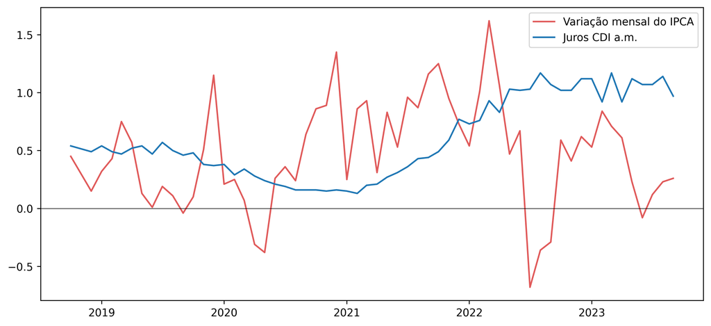

## À primeira vista:

#### **Parecem não se relacionar quantitativamente**

"O comportamento de uma não tem nada a ver com o da outra"

#### **... nem qualitativamente**

"O que juros tem a ver com inflação?"

## Aplicando soma cumulativa...

#### O comportamento parece ficar mais parecido, aqui estamos vendo o efeito acumulado da inflação, taxa de juros, e taxa de juros descontada da inflação (rentabilidade real):

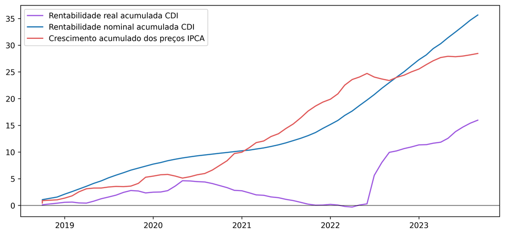

## O nível de preços na verdade está bem relacionado com a taxa de juros

- O Conselho Monetário Nacional (CMN) usa a taxa de juros para controlar a inflação *do futuro*
  - Trata-se de um jogo de expectativas
- É esperado que a taxa de juros decidida hoje tenha efeito na inflação de aproximadamente 1 ano à frente

## Encontrando a melhor correlação

#### A partir do recorte que coletamos, a melhor correlação se encontra com 14 meses de defasagem, o que se aproxima bem do que era esperado:

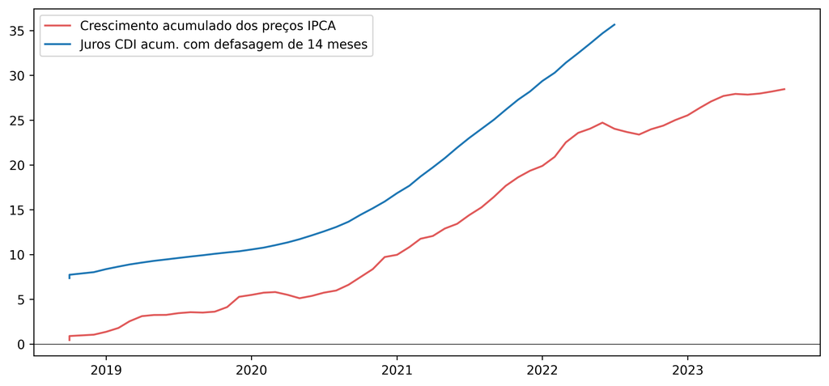

## Agora podemos usar a taxa de juros CDI para prever a inflação IPCA

#### Vamos usar uma regressão simples com este formato:

$$ \pi_{(t=14)} = \alpha i_{(t=0)} + \beta $$

Onde $\pi_{(t=14)}$ é a inflação 14 meses à frente, e $i_{(t=0)}$ é a taxa de juros no mês atual. $\alpha$ e $\beta$ são os coeficientes de inclinação e intercepto, respectivamente.

## Assim fica o ajuste do nosso modelo (nada mal!):

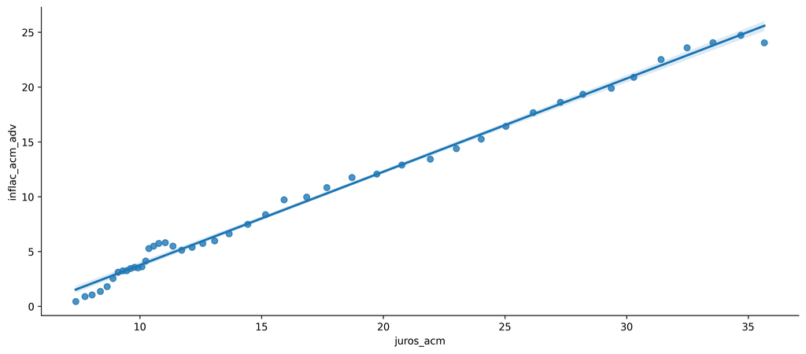

## Também podemos fazer projeções do IPCA com ele!

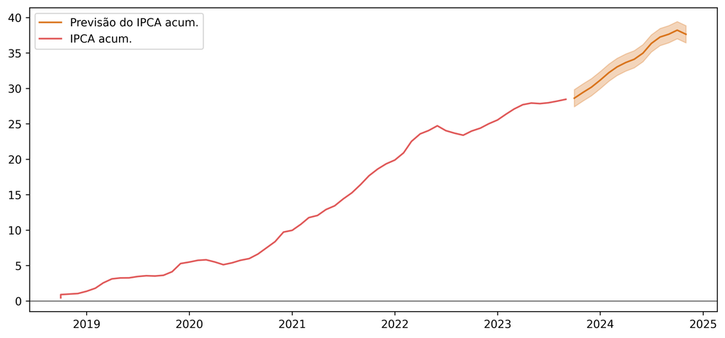

# Obrigado!

Para mais detalhes, [clique aqui](https://github.com/VFLins/Projects/blob/main/predict_ipca_with_cdi/taxa_de_juros_real.ipynb).